# Analyze Your Flickr Photostream Before You Buy a Lens

Mauricio Alarcon

May 14, 2015

## Summary

Here’s how it started. I’m looking at buying a new lens for my camera. In addition to being expensive, lenses come in a wide variety configurations. I wanna make sure I get a lens that fits my needs.

One of the main considerations when buying a lens is the focal length and speed, which heavily depend on the type of photography you do. I feel I can use some data to help assess my needs.

Modern cameras embed a lot of data in each shot. This includes: camera make and model, aperture, flash settings, etc. This information is stored as [Exchangeable Image File Format - EXIF](http://www.sno.phy.queensu.ca/~phil/exiftool/TagNames/EXIF.html) attributes.

The goal of this project is to scrape these attributes from my [Flickr Photostream](https://www.flickr.com/photos/10904202@N07/) using the [Flickr API](https://www.flickr.com/services/api/)

## The Libraries

```r
library(RCurl)
library(knitr)
library(rmongodb)
library(XML)
library(lattice)
library(ggplot2)

# Flickr API Key --- GET YOUR OWN
api_key <- "GET_YOUR_OWN_KEY_AT_FLICKR_DOT_COM"
baseURL <- paste("https://api.flickr.com/services/rest/?&format=rest&api_key=",api_key,sep="")
# we're using Mongo to store the results
m <- mongo.create()
ns <- "flickr"
```

## Finding my Flickr UserID

All I know is my username. Here, we will use Flickr’s API findByUsername method in order to obtain my UserID

```r
#
# Use findByUsername: https://www.flickr.com/services/api/explore/flickr.people.findByUsername
#

# Flickr username
user_name <- "rmalarc"

# Getting the userID
findByUsername <- paste(baseURL,"&method=flickr.people.findByUsername&username=",user_name,sep="")

findByUsername_data <- xmlRoot(xmlParse(getURL(findByUsername)))
user_id <- xmlSApply(findByUsername_data,xmlAttrs)["id",]

(user_id)
```

```
## [1] "10904202@N07"
```

## Get All My Public Photos

In this step we will get all my public photos by using the getPublicPhotos method. The list of photos is stored in a data frame.

```r
#
# Use getPublicPhotos: https://www.flickr.com/services/api/flickr.people.getPublicPhotos.html
#
getPublicPhotos <- paste(baseURL
                         ,"&method=flickr.people.getPublicPhotos&per_page=1000&user_id="
                         ,user_id
                         ,sep="")

getPublicPhotos_data <- xmlRoot(xmlParse(getURL(getPublicPhotos)))

#parse the total number of pages
pages_data <- data.frame(xmlAttrs(getPublicPhotos_data[["photos"]]))
pages_data[] <- lapply(pages_data, as.character)
pages_data[] <- lapply(pages_data, as.integer)
colnames(pages_data)<- "value"
total_pages <- pages_data["pages","value"]

photos_for_user<-NULL

# loop thru pages of photos and save the list in a DF
for(i in c(1:total_pages)){
  getPublicPhotos_data <- xmlRoot(xmlParse(getURL(getPublicPhotos)))
  tmp_df<-data.frame(t(data.frame(xmlSApply(getPublicPhotos_data[["photos"]],xmlAttrs))),stringsAsFactors=FALSE)
  tmp_df$page <- i
  photos_for_user<-rbind(photos_for_user,tmp_df)

  # get the next page
  getPublicPhotos <- paste(baseURL
                           ,"&method=flickr.people.getPublicPhotos&per_page=1000&user_id="
                           ,user_id,"&page="
                           ,i+1,sep="")
  getPublicPhotos_data <- xmlRoot(xmlParse(getURL(getPublicPhotos)))

}

kable(head(photos_for_user))
```

|  | id | owner | secret | server | farm | title | ispublic | isfriend | isfamily | page |
| --- | --- | --- | --- | --- | --- | --- | --- | --- | --- | --- |
| photo | 17011910768 | 10904202@N07 | 7ab8396b7d | 7627 | 8 |  | 1 | 0 | 0 | 1 |
| photo.1 | 17196870332 | 10904202@N07 | 259eff77f2 | 8793 | 9 |  | 1 | 0 | 0 | 1 |
| photo.2 | 17197945231 | 10904202@N07 | e6b2ed22d1 | 8817 | 9 |  | 1 | 0 | 0 | 1 |
| photo.3 | 16576089414 | 10904202@N07 | e9c6ca917a | 5334 | 6 |  | 1 | 0 | 0 | 1 |
| photo.4 | 17196868242 | 10904202@N07 | f9ef8f0425 | 8731 | 9 |  | 1 | 0 | 0 | 1 |
| photo.5 | 16578337763 | 10904202@N07 | d9112cda3f | 7690 | 8 |  | 1 | 0 | 0 | 1 |

## Select the Photos to Process

The purpose of this script is to process new photos from my photo stream. Previous data is stored in MongoDB. Here, we will select photos not yet processed.

```r
# get previously processed photos
entry_type <- "photos_exif"
coll<-paste(ns,entry_type,sep=".")

entries_processed <- NULL
cursor<-mongo.find(m
                    ,coll
                    ,query = mongo.bson.empty()
                    ,fields=list(photo_id=1L)
                    )
entries_processed <- mongo.cursor.to.data.frame(cursor,stringsAsFactors=FALSE)
mongo.cursor.destroy(cursor)
```

```
## [1] FALSE
```

```r
# process records not already processed
entries_to_process <- photos_for_user[!(photos_for_user$id %in% entries_processed$photo_id),]


kable(head(entries_to_process))
```

## Get Exif Photo Attributes

Now it’s time to get those Exif attributes for my pictures. We will use the getExif method from the Flicker API. Results are stored into MongoDB.

```r
#
# Use getExif: https://www.flickr.com/services/api/flickr.photos.getExif.html
#

photos_exif <-NULL
for(photo_id in entries_to_process$id){
  Sys.sleep(0.5)

  #photo_id<-photos_for_user$id[1]
  getExif <- paste(baseURL,"&method=flickr.photos.getExif&photo_id=",photo_id,sep="")
  getExif_data <- xmlRoot(xmlParse(getURL(getExif)))

  # get the exif attribute name
  tmp_df<-data.frame(xmlSApply(getExif_data[["photo"]],xmlAttrs),stringsAsFactors=FALSE)
  colnames(tmp_df)<-tmp_df["tag",]

  # get the exif attribute raw values
  tmp_df_val<-data.frame(t(data.frame(xmlSApply(getExif_data[["photo"]],xmlValue))),stringsAsFactors=FALSE)

  # name the column after the attribute name
  colnames(tmp_df_val)<-tmp_df["tag",]

  # add a photo_id column and rowname
  tmp_df_val$photo_id <- photo_id
  row.names(tmp_df_val)<-photo_id
  colnames(photos_exif)

  # export to mongo
  mongo.insert(m, coll,mongo.bson.from.JSON(toJSON(tmp_df_val)))
#  photos_exif<-rbind.fill(photos_exif,tmp_df_val)
}
```

## Load Processed Photo Attributes

In this step, we will load all previously loaded data.

```r
photos_exif <- NULL
cursor<-mongo.find(m
                    ,coll
                    ,query = mongo.bson.empty()
                    )
photos_exif <- mongo.cursor.to.data.frame(cursor)
mongo.cursor.destroy(cursor)
```

```
## [1] FALSE
```

```r
kable(head(photos_exif))
```

| Make | Model | XResolution | YResolution | ResolutionUnit | Software | ModifyDate | ExifVersion | FocalPlaneXResolution | FocalPlaneYResolution | FocalPlaneResolutionUnit | Compression | ResolutionUnit.1 | ThumbnailOffset | ThumbnailLength | DisplayedUnitsX | DisplayedUnitsY | PhotoshopThumbnail | IPTCDigest | CodedCharacterSet | ApplicationRecordVersion | ObjectName | ViewingCondIlluminant | ViewingCondSurround | ViewingCondIlluminantType | MeasurementObserver | MeasurementBacking | MeasurementGeometry | MeasurementFlare | MeasurementIlluminant | … |
| --- | --- | --- | --- | --- | --- | --- | --- | --- | --- | --- | --- | --- | --- | --- | --- | --- | --- | --- | --- | --- | --- | --- | --- | --- | --- | --- | --- | --- | --- | --- |
| TBD | TBD | 240240 dpi | 240240 dpi | inches | Adobe Photoshop Lightroom 3.4.1 | 2011:07:03 13:07:36 | 0230 | 0 | 0 | Unknown (0) | JPEG (old-style) | inches | 354 | 12298 | inches | inches | (Binary data 12298 bytes, use -b option to extract) | 149c06d715d3551c5208f774f6e505b4 | UTF8 | 4 | Nevermind | 19.6445 20.3718 16.8089 | 3.92889 4.07439 3.36179 | D50 | CIE 1931 | 0 0 0 | Unknown (0) | 0.999% | D65 | … |
| NIKON CORPORATION | NIKON D3100 | 240240 dpi | 240240 dpi | inches | Adobe Photoshop Lightroom 3.4.1 | 2011:07:03 11:56:03 | 0230 | NA | NA | NA | JPEG (old-style) | inches | 936 | 10854 | inches | inches | (Binary data 10854 bytes, use -b option to extract) | b5f5079d6b4add09c68e161d71c9b86a | UTF8 | 4 | Rockets | 19.6445 20.3718 16.8089 | 3.92889 4.07439 3.36179 | D50 | CIE 1931 | 0 0 0 | Unknown (0) | 0.999% | D65 | … |
| NIKON CORPORATION | NIKON D3100 | 240240 dpi | 240240 dpi | inches | Adobe Photoshop Lightroom 3.4.1 | 2011:07:04 15:27:02 | 0230 | NA | NA | NA | JPEG (old-style) | inches | 936 | 8614 | inches | inches | (Binary data 8614 bytes, use -b option to extract) | 9557bb826024486e623b21ad55304211 | UTF8 | 4 | NA | 19.6445 20.3718 16.8089 | 3.92889 4.07439 3.36179 | D50 | CIE 1931 | 0 0 0 | Unknown (0) | 0.999% | D65 | … |
| TBD | TBD | 240240 dpi | 240240 dpi | inches | Adobe Photoshop Lightroom 3.4.1 | 2011:07:02 08:50:10 | 0230 | 0 | 0 | Unknown (0) | JPEG (old-style) | inches | 386 | 15578 | inches | inches | (Binary data 15578 bytes, use -b option to extract) | 9dfd812a07083bd41a91a33c4d41da73 | UTF8 | 4 | NA | 19.6445 20.3718 16.8089 | 3.92889 4.07439 3.36179 | D50 | CIE 1931 | 0 0 0 | Unknown (0) | 0.999% | D65 | … |
| NIKON CORPORATION | NIKON D3100 | 240240 dpi | 240240 dpi | inches | Adobe Photoshop Lightroom 3.4.1 | 2011:07:04 15:27:03 | 0230 | NA | NA | NA | JPEG (old-style) | inches | 936 | 7078 | inches | inches | (Binary data 7078 bytes, use -b option to extract) | 3b7b969da8aea50c7e54f614798f3d98 | UTF8 | 4 | NA | 19.6445 20.3718 16.8089 | 3.92889 4.07439 3.36179 | D50 | CIE 1931 | 0 0 0 | Unknown (0) | 0.999% | D65 | … |
| NIKON | COOLPIX S8100 | 240240 dpi | 240240 dpi | inches | Adobe Photoshop Lightroom 3.4.1 | 2011:06:12 11:33:33 | 0230 | NA | NA | NA | JPEG (old-style) | inches | 750 | 12103 | inches | inches | (Binary data 12103 bytes, use -b option to extract) | f6f31c84f2afc6b5297389c99dcfc39e | UTF8 | 4 | NA | 19.6445 20.3718 16.8089 | 3.92889 4.07439 3.36179 | D50 | CIE 1931 | 0 0 0 | Unknown (0) | 0.999% | D65 | … |

```r
#photos_exif_old <-photos_exif
#apply(photos_for_user,1,function(results){
#  mongo.insert(m, coll,mongo.bson.from.JSON(toJSON(results)))})
```

## Cleaning Up the Data

```r
attr<-photos_exif[photos_exif$Model == "NIKON D3100"
                  ,c("photo_id"
                    ,"Model"
                    ,"Lens"
                    ,"FocalLength"
                    ,"FNumber"
                    ,"MaxApertureValue"
                    ,"ISO"
                    ,"ExposureTime"
                    ,"GainControl"
                    ,"Flash"
                    ,"LightSource"
                    ,"DateTimeOriginal")]


attr$Lens[grep("18-270mm",attr$Lens)] <- "18-270mm f/3.5-6.3"
attr$Lens[grep("18\\.0-270\\.0",attr$Lens)] <- "18-270mm f/3.5-6.3"
attr$Lens[grep("18\\.0-55\\.0",attr$Lens)] <- "18-55mm f/3.5-5.6"
attr$Lens[grep("55\\.0-200\\.0",attr$Lens)] <- "55-200mm f/4-5.6"
attr$Lens<-as.character(attr$Lens)
attr$ExposureTime<-as.character(attr$ExposureTime)


attr$FocalLength_clean <- as.numeric(gsub("^\\d+\\.\\d+ +mm(.+) +mm","\\1",attr$FocalLength,fixed = FALSE ))
attr$FNumber_clean <- as.numeric(gsub("^.+\\/(.+)","\\1",attr$FNumber,fixed = FALSE ))
attr$ExposureTime_clean <- as.integer(gsub(".*\\/([0-9]+)\\)$","\\1",attr$ExposureTime))
attr$FocalLength_disc <- cut(attr$FocalLength_clean, breaks = c(0,25, 50, 75, 100,150, 300))
```

## Analysing the Data

### Lens Utilization

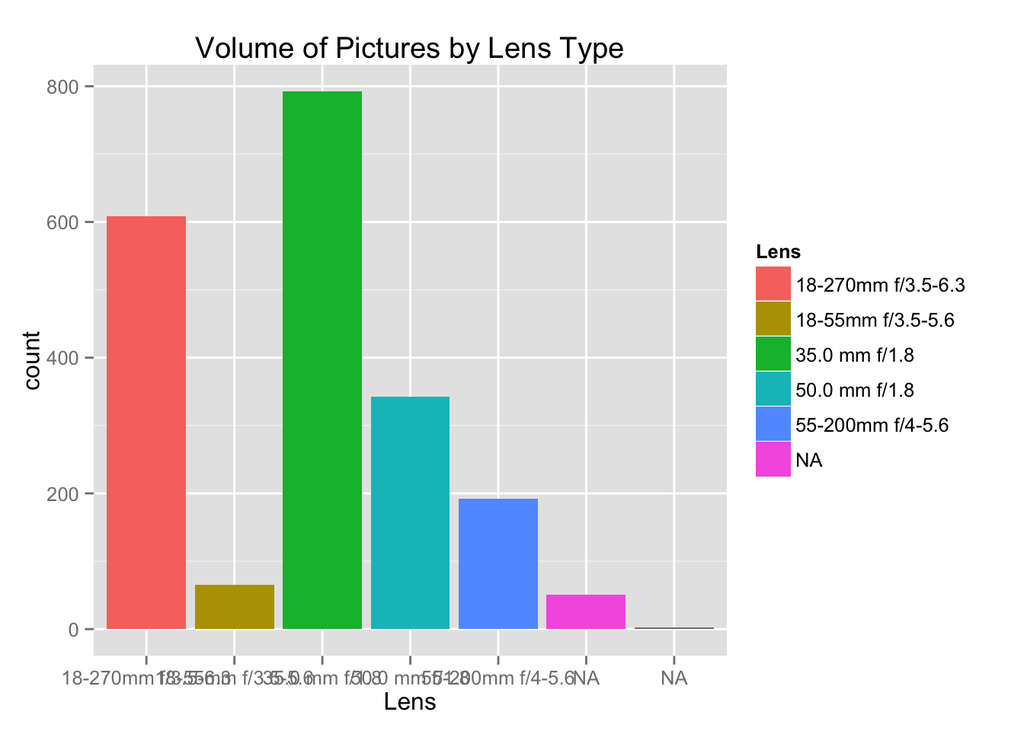

```r
p <- qplot(Lens, data=attr, geom="bar", fill=Lens)
p + labs(title = "Volume of Pictures by Lens Type")
```

As we can see, I definitely use my prime lens a lot more than the others, even the fancy 18-270mm zoom lens.

### Focal Length Utilization

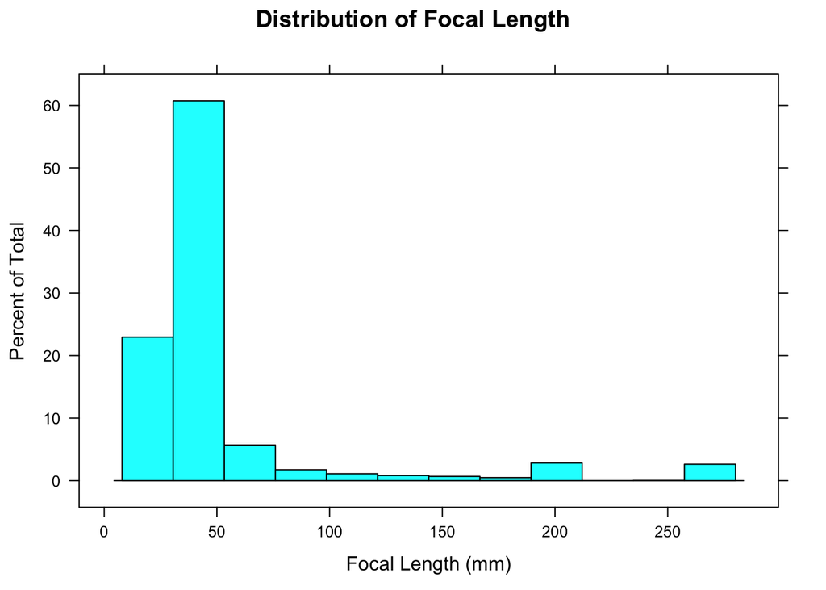

```r
histogram(~FocalLength_clean, data = attr,
          main="Distribution of Focal Length",
          xlab="Focal Length (mm)")
```

```r
fl_freq<-data.frame(table(attr$FocalLength_disc)/sum(table(attr$FocalLength_disc)))
colnames(fl_freq)<-c("Focal Length","Frequency")
kable(fl_freq)
```

| Focal Length | Frequency |
| --- | --- |
| (0,25] | 0.2017587 |
| (25,50] | 0.6365413 |
| (50,75] | 0.0576453 |
| (75,100] | 0.0205178 |
| (100,150] | 0.0195408 |
| (150,300] | 0.0639961 |

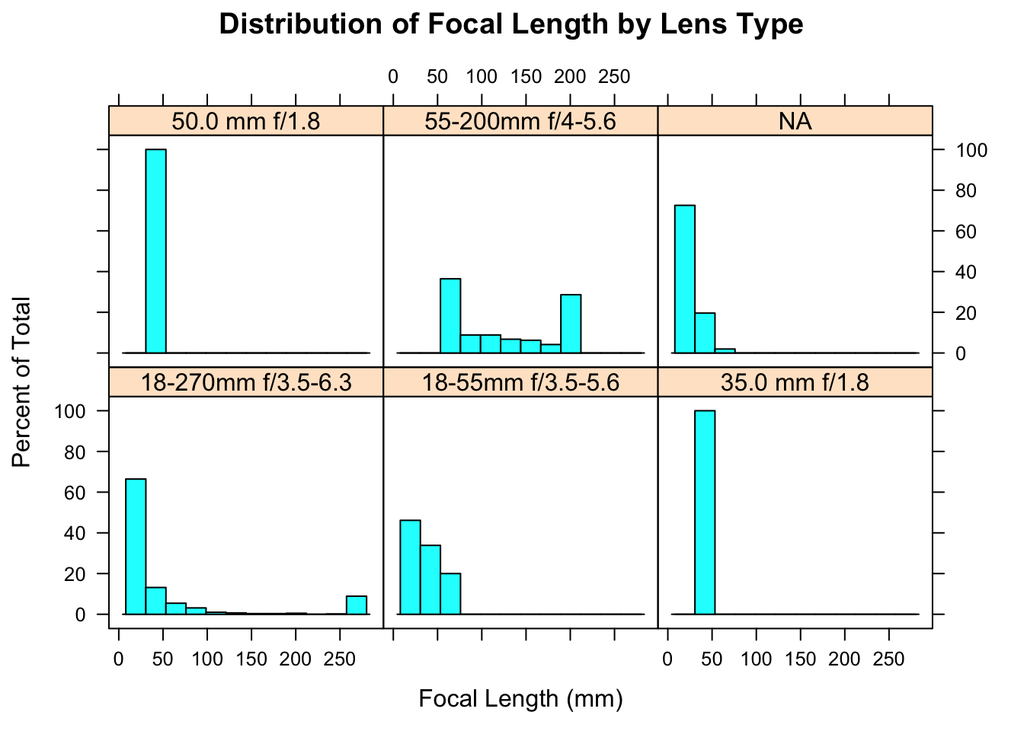

```r
histogram(~FocalLength_clean | Lens, data = attr,
          main="Distribution of Focal Length by Lens Type",
          xlab="Focal Length (mm)")
```

### f-Number and Exposure Time Analysis

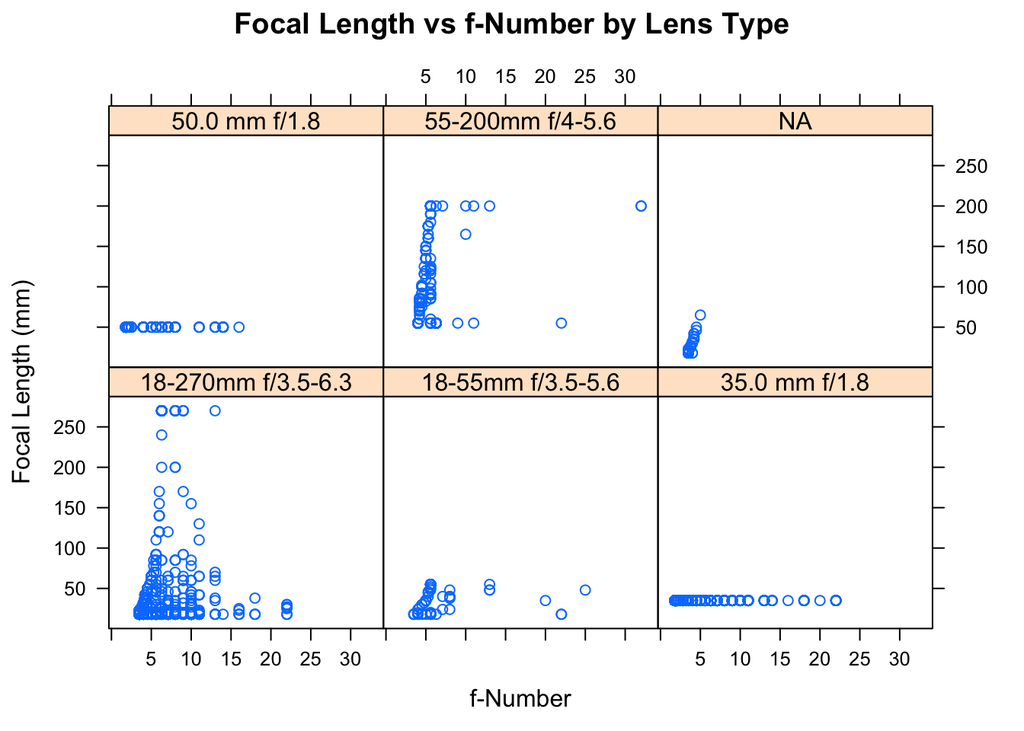

```r
xyplot(FocalLength_clean~FNumber_clean|Lens, data=attr,
   main = "Focal Length vs f-Number by Lens Type",
   xlab = "f-Number", ylab = "Focal Length (mm)")
```

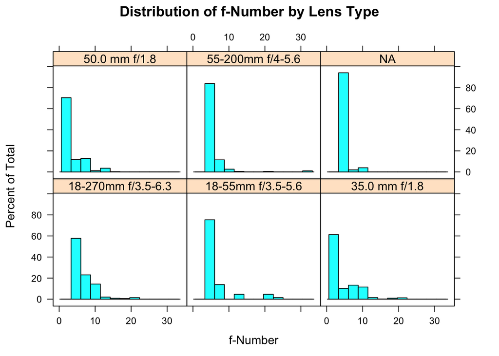

```r
histogram(~FNumber_clean | Lens, data = attr,
          main="Distribution of f-Number by Lens Type",
          xlab="f-Number")
```

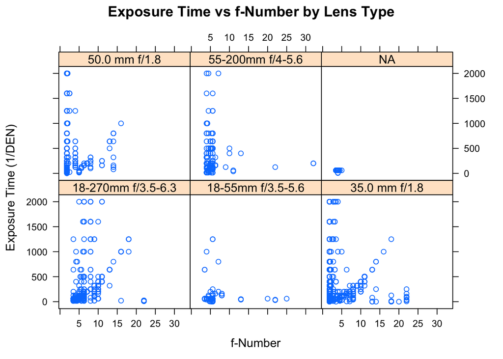

```r
xyplot(ExposureTime_clean~FNumber_clean|Lens, data=attr,
   main = "Exposure Time vs f-Number by Lens Type",
   xlab = "f-Number", ylab = "Exposure Time (1/DEN)")
```

As we can see from the charts above, I tend to shoot my pictures on with a low f-number, regardless of the lens and exposure time.

## Let’s do some statistical tests..

### First one: Let’s prove that hardly ever use zoom settings over 100mm

- H0: My utilization of high-zoom (>100mm) values is random P(X>100)>0.95
- H1: I consistently utilize high-zoom in my pictures P(X>100)<=0.95

```r
#Let's calculate the mean and standard deviation for my 17-270mm lens
fl_17_2170 <- attr[attr$Lens=="18-270mm f/3.5-6.3" &!is.na(attr$FocalLength_clean),]



mean_fl <- mean(fl_17_2170$FocalLength_clean)
sd_fl <- sd(fl_17_2170$FocalLength_clean)

pnorm(100,mean_fl,sd_fl)
```

```
## [1] 0.7400844
```

With a p of 0.74, we must reject the null hypothesis and accept that I do utilize consistently zoom settings greater than 100mm

```r
qnorm(0.95,mean_fl,sd_fl)
```

```
## [1] 173.0482
```

According tpo the value above, it makes sense to buy a lens with a zoom up to 173mm

### Notes on the tests

The above tests imply that zoom values follow a normal distribition, which as we look at the below histogram does not appear to be the case.

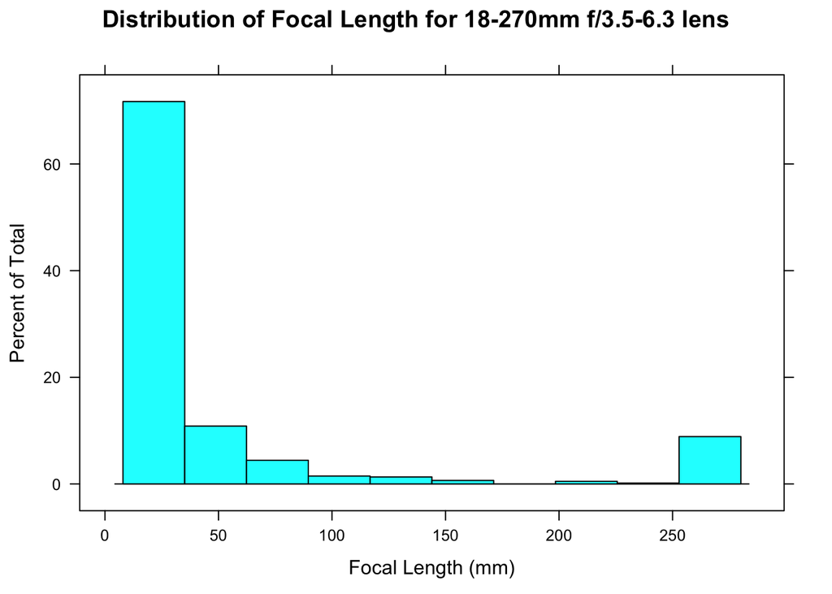

```r
histogram(~FocalLength_clean, data = fl_17_2170,
          main="Distribution of Focal Length for 18-270mm f/3.5-6.3 lens",
          xlab="Focal Length (mm)")
```

## Conclusion

Based on my photographic history, there’s no need to go for a big zoom lens. Despite of the evidence, I should be fine if I choose a lens that goes up to 100mm. Instead, I should focus on a lens that offers the lowest f-number.